# Cartesian Consulting- Analytics Vidhya

## Twitter Sentiment classification

```python
import numpy as np
import pandas as pd
import matplotlib.pyplot as plt
import seaborn as sns
from imblearn.over_sampling import SMOTE
sns.set_style('darkgrid')
import warnings
warnings.filterwarnings("ignore")
```

## Loading Dataset

```python
df_train = pd.read_csv('train_E6oV3lV.csv')
df_test = pd.read_csv('test_tweets_anuFYb8.csv')
```

```python
df_train.head()
```

|  | id | label | tweet |
| --- | --- | --- | --- |
| 0 | 1 | 0 | @user when a father is dysfunctional and is s... |
| 1 | 2 | 0 | @user @user thanks for #lyft credit i can't us... |
| 2 | 3 | 0 | bihday your majesty |
| 3 | 4 | 0 | #model i love u take with u all the time in ... |
| 4 | 5 | 0 | factsguide: society now #motivation |

```python
df = pd.concat([df_train.drop('label', axis=1),df_test],axis=0)
df.shape
```

```
(49159, 2)
```

```python
df.head()
```

|  | id | tweet |
| --- | --- | --- |
| 0 | 1 | @user when a father is dysfunctional and is s... |
| 1 | 2 | @user @user thanks for #lyft credit i can't us... |
| 2 | 3 | bihday your majesty |
| 3 | 4 | #model i love u take with u all the time in ... |
| 4 | 5 | factsguide: society now #motivation |

```python
df.info()
```

```
<class 'pandas.core.frame.DataFrame'>
Int64Index: 49159 entries, 0 to 17196
Data columns (total 2 columns):
id       49159 non-null int64
tweet    49159 non-null object
dtypes: int64(1), object(1)
memory usage: 1.1+ MB
```

```python
df_test.head()
```

|  | id | tweet |
| --- | --- | --- |
| 0 | 31963 | #studiolife #aislife #requires #passion #dedic... |
| 1 | 31964 | @user #white #supremacists want everyone to s... |
| 2 | 31965 | safe ways to heal your #acne!! #altwaystohe... |
| 3 | 31966 | is the hp and the cursed child book up for res... |
| 4 | 31967 | 3rd #bihday to my amazing, hilarious #nephew... |

We have a dataset of tweets along with their labels. **'1'** denotes that tweet contains negative sentiment and **'0'** denotes tweet does not contain negative sentiment.

## Exploratory Data analysis

Creating 1 extra column in dataframe to display the length of each tweet.

```python
df_train['tweet_length'] = [len(i) for i in df_train['tweet']]
df_train.head()
```

|  | id | label | tweet | tweet_length |
| --- | --- | --- | --- | --- |
| 0 | 1 | 0 | @user when a father is dysfunctional and is s... | 102 |
| 1 | 2 | 0 | @user @user thanks for #lyft credit i can't us... | 122 |
| 2 | 3 | 0 | bihday your majesty | 21 |
| 3 | 4 | 0 | #model i love u take with u all the time in ... | 86 |
| 4 | 5 | 0 | factsguide: society now #motivation | 39 |

```python
df.info()
```

[output not shown]

There is a class imbalance in our dataset. Tweets with label **'1'** are significantly less than tweets with label **'0'**.

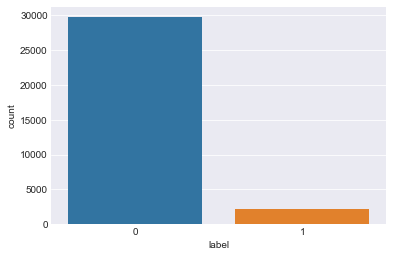

```
0    29720
1     2242
Name: label, dtype: int64
```

```python
sns.countplot(df_train['label']);
plt.show();
print(df_train['label'].value_counts())
```

```python
df_train.iloc[0,2]
```

```
' @user when a father is dysfunctional and is so selfish he drags his kids into his dysfunction.   #run'
```

```python
df_train['tweet_length'].describe()
```

```
count    31962.000000
mean        84.739628
std         29.455749
min         11.000000
25%         63.000000
50%         88.000000
75%        108.000000
max        274.000000
Name: tweet_length, dtype: float64
```

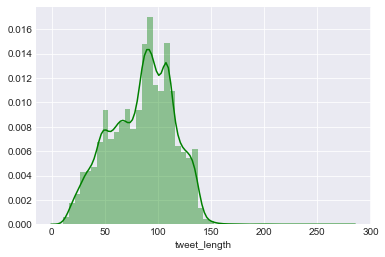

```python
sns.distplot(df_train['tweet_length'], color='green');
plt.show();
```

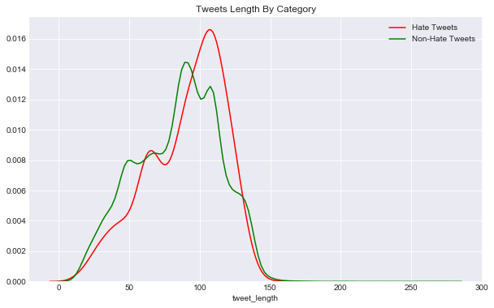

```python
plt.figure(figsize=(10,6));
sns.distplot(df_train[df_train['label'] == 1]['tweet_length'], hist=False, color='red', label='Hate Tweets');
sns.distplot(df_train[df_train['label'] == 0]['tweet_length'], hist=False, color='green', label='Non-Hate Tweets');
plt.title('Tweets Length By Category')
plt.legend();
plt.show();
```

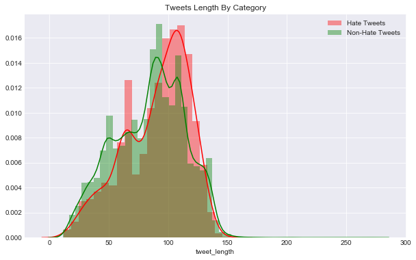

```python
plt.figure(figsize=(10,6));
sns.distplot(df_train[df_train['label'] == 1]['tweet_length'], color='red', label='Hate Tweets');
sns.distplot(df_train[df_train['label'] == 0]['tweet_length'], color='green', label='Non-Hate Tweets');
plt.title('Tweets Length By Category')
plt.legend();
plt.show();
```

## Cleaning Data & Transformation

Importing Natural Language Processing libraries

```python
import string
from nltk import ngrams
import re
from nltk.corpus import stopwords
from sklearn.feature_extraction.text import CountVectorizer, TfidfTransformer

print('Punctuation Words: ',string.punctuation)
```

```
Punctuation Words:  !"#$%&'()*+,-./:;<=>?@[\]^_`{|}~
```

```python
def text_clean(text):
    no_punctuation = [i for i in text if i not in string.punctuation]
    no_punctuation = ''.join(no_punctuation)
    words = [word.lower() for word in no_punctuation.split() if word.lower() not in stopwords.words('english')]
    return words
```

Creating text_clean function, that'll do 2 things

1. Remove Punctuation words
2. Convert each letter into lowercase and remove **Stopwords**

Here is what this function will do

```python
df_train['tweet'].head().apply(text_clean)
```

```
0    [user, father, dysfunctional, selfish, drags, ...
1    [user, user, thanks, lyft, credit, cant, use, ...
2                                    [bihday, majesty]
3    [model, love, u, take, u, time, urð±, ðð...
4                    [factsguide, society, motivation]
Name: tweet, dtype: object
```

## Count Vectorizer

Convert a collection of text documents to a matrix of token counts. For more details click [here](http://scikit-learn.org/stable/modules/generated/sklearn.feature_extraction.text.CountVectorizer.html)

```python
c_vectorizer = CountVectorizer(analyzer=text_clean)
tweets_vector = c_vectorizer.fit(df['tweet']) #Fitting CountVectorizer
```

We can get the feature names by their respective **feature integer**

```python
tweets_vector.get_feature_names()[3012]
```

```
'alexandre'
```

Transforming the whole **tweet** column

```python
tweet_bow = tweets_vector.transform(df['tweet'])
type(tweet_bow)
```

```
scipy.sparse.csr.csr_matrix
```

## Tfidf Transformation

Transform a count matrix to a normalized **term frequency-inverse frequency document** representation. For more details click [here](http://scikit-learn.org/stable/modules/generated/sklearn.feature_extraction.text.TfidfTransformer.html)

```python
tfidf_transform = TfidfTransformer()
tfidf_transform.fit(tweet_bow)
```

```
TfidfTransformer(norm='l2', smooth_idf=True, sublinear_tf=False, use_idf=True)
```

```python
print(tfidf_transform)
```

```
TfidfTransformer(norm='l2', smooth_idf=True, sublinear_tf=False, use_idf=True)
```

```python
tweets_tfidf = tfidf_transform.transform(tweet_bow)
```

```python
tweets_vector.get_feature_names()[14029]
```

```
'dedication'
```

## Machine Learning: Classification

```python
X_train = tweets_tfidf[:31962,:]
X_test = tweets_tfidf[31962:,:]

y = df_train['label']
X_test
```

```
<17197x63039 sparse matrix of type '<class 'numpy.float64'>'
	with 141858 stored elements in Compressed Sparse Row format>
```

## Oversampling

```python
sm = SMOTE(random_state=42, ratio=1.0)

X_over, y_over = sm.fit_sample(X_train, y)
```

```python
from sklearn.naive_bayes import MultinomialNB
from sklearn.ensemble import RandomForestClassifier

naive_model = MultinomialNB()
naive_model.fit(X_over, y_over)
```

```
MultinomialNB(alpha=1.0, class_prior=None, fit_prior=True)
```

```python
rf = RandomForestClassifier(n_estimators=50, random_state=42)
rf.fit(X_over, y_over)
```

```
RandomForestClassifier(bootstrap=True, class_weight=None, criterion='gini',
            max_depth=None, max_features='auto', max_leaf_nodes=None,
            min_impurity_decrease=0.0, min_impurity_split=None,
            min_samples_leaf=1, min_samples_split=2,
            min_weight_fraction_leaf=0.0, n_estimators=50, n_jobs=1,
            oob_score=False, random_state=42, verbose=0, warm_start=False)
```

## Model Evaluation

#### Cross Validation score

```python
from sklearn.model_selection import cross_val_score

cv_rf = np.mean(cross_val_score(rf, X_train, y, cv=5))
cv_nb = np.mean(cross_val_score(naive_model, X_train, y, cv=5))
print('Mean CV score of Random Forest = ', cv_rf)
print('Mean CV score of Naive Bayes = ', cv_nb)
```

```
Mean CV score of Random Forest =  0.958262948739107
Mean CV score of Naive Bayes =  0.9376447066341138
```

```python
from sklearn.metrics import accuracy_score, confusion_matrix
from sklearn.metrics import classification_report

#This function will print model accuracy and other evaluation measures
def metrics(X, y, model_name):
    predictions = model_name.predict(X)
    print('Accuracy Score: ', accuracy_score(y, predictions))
    print(classification_report(y, predictions))
    cm = confusion_matrix(y,predictions)
    plt.figure(figsize=(5,4));
    sns.heatmap(cm, annot=True, linewidths=0.8, cmap = 'icefire_r', fmt='.2f');
    plt.title('Confusion-Matrix')
    plt.xlabel('Predicted Class');
    plt.ylabel('Actual Class');
    return plt.show();
```

#### Random Forest Model Evaluation

```
Accuracy Score:  0.9998822341857335
             precision    recall  f1-score   support

          0       1.00      1.00      1.00     29720
          1       1.00      1.00      1.00     29720

avg / total       1.00      1.00      1.00     59440
```

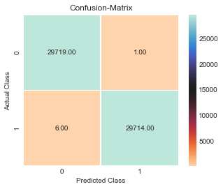

```python
metrics(X_over, y_over, rf)
```

#### Naive Bayes Model Evaluation

```
Accuracy Score:  0.9735868102288021
             precision    recall  f1-score   support

          0       1.00      0.95      0.97     29720
          1       0.95      1.00      0.97     29720

avg / total       0.97      0.97      0.97     59440
```

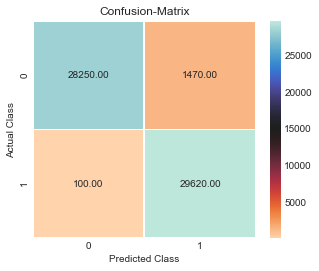

```python
metrics(X_over, y_over, naive_model)
```

Copying model predictions into excel file. I am submitting predictions of **Random Forest** model beacause model is performing really well on this data.

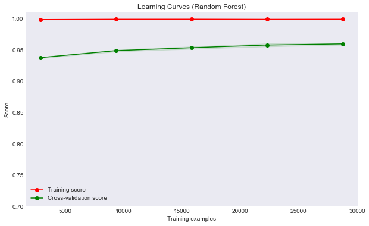

```python
from sklearn.model_selection import learning_curve

def plot_learning_curve(estimator, title, X, y, ylim=None, cv=None,
                        n_jobs=1, train_sizes=np.linspace(.1, 1.0, 5)):

    plt.figure(figsize=(10,6))
    plt.title(title)
    if ylim is not None:
        plt.ylim(*ylim)
    plt.xlabel("Training examples")
    plt.ylabel("Score")
    train_sizes, train_scores, test_scores = learning_curve(
        estimator, X, y, cv=cv, n_jobs=n_jobs, train_sizes=train_sizes)
    train_scores_mean = np.mean(train_scores, axis=1)
    train_scores_std = np.std(train_scores, axis=1)
    test_scores_mean = np.mean(test_scores, axis=1)
    test_scores_std = np.std(test_scores, axis=1)
    plt.grid()

    plt.fill_between(train_sizes, train_scores_mean - train_scores_std,
                     train_scores_mean + train_scores_std, alpha=0.1,
                     color="r")
    plt.fill_between(train_sizes, test_scores_mean - test_scores_std,
                     test_scores_mean + test_scores_std, alpha=0.1, color="g")
    plt.plot(train_sizes, train_scores_mean, 'o-', color="r",
             label="Training score")
    plt.plot(train_sizes, test_scores_mean, 'o-', color="g",
             label="Cross-validation score")

    plt.legend(loc="best")
    return plt

title_rf = "Learning Curves (Random Forest)"
title_nb = 'Learning Curves (Naive Bayes)'
plot_learning_curve(rf, title_rf, X_train, y, ylim=(0.7, 1.01), cv=10, n_jobs=1);
plt.show();
```

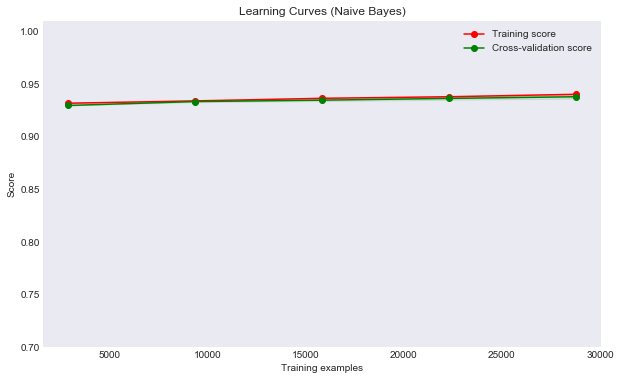

```python
plot_learning_curve(naive_model, title_nb, X_train, y, ylim=(0.7, 1.01), cv=10, n_jobs=1);
plt.show()
```

## Predicting On Test Data

```python
df_test['label'] = rf.predict(X_test)
df_test[['id', 'label']].to_csv('AV_comp.csv', index=False)
```

## Further Improvements

Random Forest and Naive Bayes model is performing well on this data, so there is no need to build highly complex model by hyperparameter tuning. But here are somethings we can do to improve the generalization power of this model.

1. Building model with **Bi-grams**, **Tri-grams**
2. Tuning Parameters of Random Forest model such as n_estimators, max_depth etc using **GridSearchCV**
3. Using **TextBlob**, sentiment scores of each tweet
4. Test other good classification model such as **Support Vector**